# Tree Sound Absorption

Linking Structural Traits to Acoustic Attenuation

Anna

## Acoustic Pipeline

1. Baseline Reference
2. Trim Signals
3. Deconvolve → Impulse Response
4. Window IR
5. Extract Transfer Function
6. Compute Attenuation Metrics

## Step 1: Baseline Reference in Frequency domain

```python
def baseline_reference(recording, reference):
    ...
    # Match low-frequency baseline (first 200 bins ≈ 200 Hz)
    low_bins = 200
    shift_db = np.mean(rec_mag_db[:low_bins]) - np.mean(ref_mag_db[:low_bins])

    # Apply shift to reference
    ref_mag_db_shifted = ref_mag_db + shift_db
    ...
```

## Step 2: Trim Signals

```python
def trim_signals(recording, reference, threshold_rel=0.02):
    ...
    # Find robust onset (check local mean to avoid spikes)
    check_window = int(round(1e-3 * fs))  # 1 ms window
    valid_start = None

    for idx in above:
        lo = max(0, idx - check_window)
        hi = min(len(abs_sig), idx + check_window)
        local_mean = np.mean(abs_sig[lo:hi])

        if local_mean > 0.5 * thresh:
            valid_start = idx
            break

    if valid_start is None:
        valid_start = int(above[0])

    # Apply safety margin
    margin_samples = int(round(safety_margin_ms * 1e-3 * fs))
    start_idx = max(0, valid_start - margin_samples)

    # Trim both signals (reference and recording)
    rec_data = arr[start_idx:] if arr.ndim == 1 else arr[start_idx:, :]
    rec_trimmed = slab.Sound(data=rec_data, samplerate=fs)

    ref_data = np.asarray(reference.data)
    ref_data = ref_data[start_idx:] if ref_data.ndim == 1 else ref_data[start_idx:, :]
    ref_trimmed = slab.Sound(data=ref_data, samplerate=reference.samplerate)

    return rec_trimmed, ref_trimmed, start_idx
```

## Step 3: Deconvolution

$$H(f) = \frac{Y(f)}{X(f)}$$

```python
def deconvolve(recording, reference, freq_range=(125, 18000)):
    ...
    # Regularized inversion prevents division by small values
    # at frequencies where reference has low energy
    ref_inv = pyfar.dsp.regularized_spectrum_inversion(
        ref_pf, frequency_range=freq_range # <- adjusted to range of speaker
    )

    # Deconvolution: multiplication in frequency domain
    ir_full = rec_pf * ref_inv

    return ir_full
```

## Step 4: Window the IR

```python
def window_ir(ir_full, fade_in_ms=0.25, sustain_ms=4.8, fade_out_ms=1.0):
    ...
    # Detect IR onset using threshold method
    onset_idx = int(pyfar.dsp.find_impulse_response_start(
        ir_full, threshold=20
    )[0])

    # Calculate window boundaries in samples
    fade_in_start = onset_idx - int(fade_in_ms * 1e-3 * fs)
    fade_in_end = onset_idx
    fade_out_start = onset_idx + int(sustain_ms * 1e-3 * fs)
    fade_out_end = onset_idx + int((sustain_ms + fade_out_ms) * 1e-3 * fs)
    ...
    # Apply Hann window <- fade in an out instead of cut-off
    ir_windowed, window = pyfar.dsp.time_window(
        ir_full, samples, "hann", unit="samples", crop="end", return_window=True
    )
    ...
```

## Effect of Windowing after Deconvolution

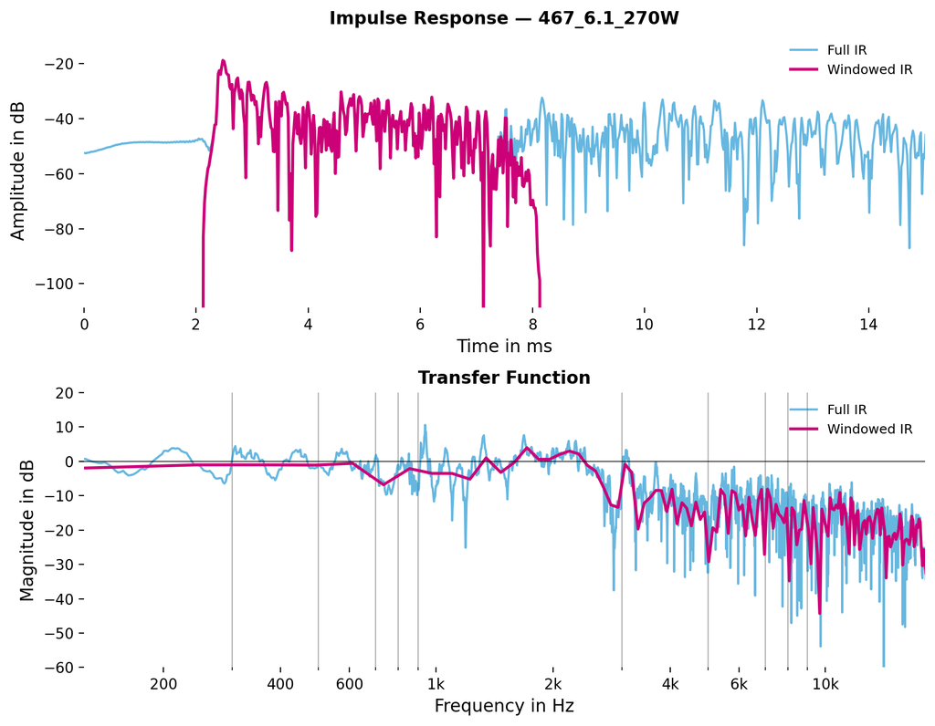

## Step 6: Attenuation Metrics

```python
# Band definitions for attenuation metrics (Hz)
BAND_LOW = (125, 500) # traffic, machinery
BAND_MID = (500, 2000) # human speech
BAND_HIGH = (2000, 18000) # bird songs

def compute_attenuation_metrics(freqs, tf_db):
    ...
    # Overall attenuation (full range)
    mask_all = (freqs >= FREQ_LOW) & (freqs <= FREQ_HIGH)
    self.attenuation_overall = float(np.mean(tf_db[mask_all]))

    # Low band
    mask_low = (freqs >= BAND_LOW[0]) & (freqs < BAND_LOW[1])
    self.attenuation_low = float(np.mean(tf_db[mask_low]))

    # Mid band
    mask_mid = (freqs >= BAND_MID[0]) & (freqs < BAND_MID[1])
    self.attenuation_mid = float(np.mean(tf_db[mask_mid]))

    # High band
    mask_high = (freqs >= BAND_HIGH[0]) & (freqs <= BAND_HIGH[1])
    self.attenuation_high = float(np.mean(tf_db[mask_high]))
```

## Step 6: Attenuation Metrics

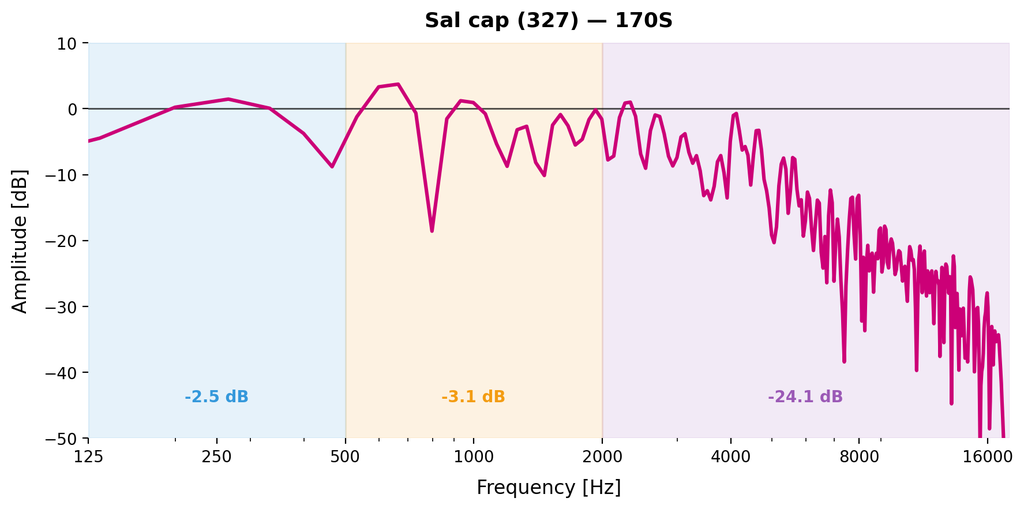

## All Transfer Functions

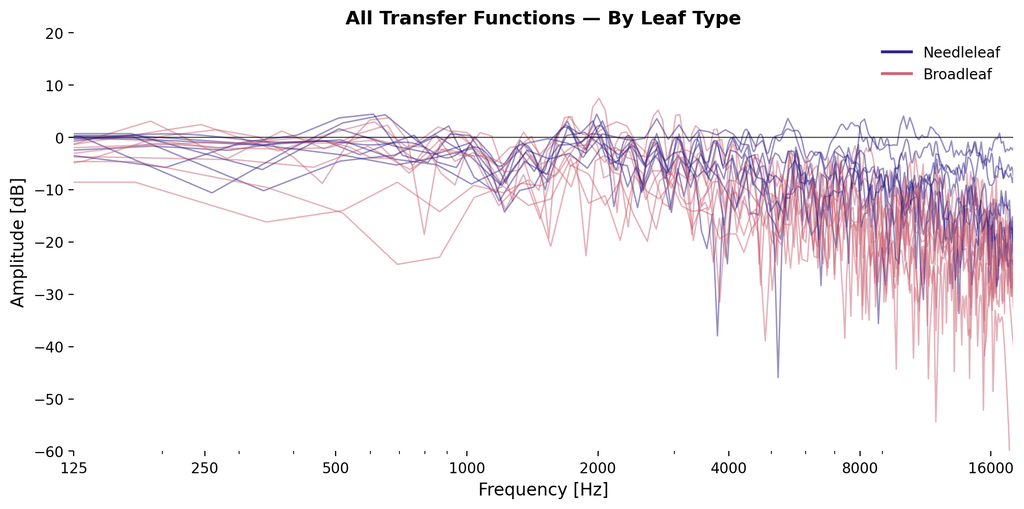

## Attenuation Heatmap

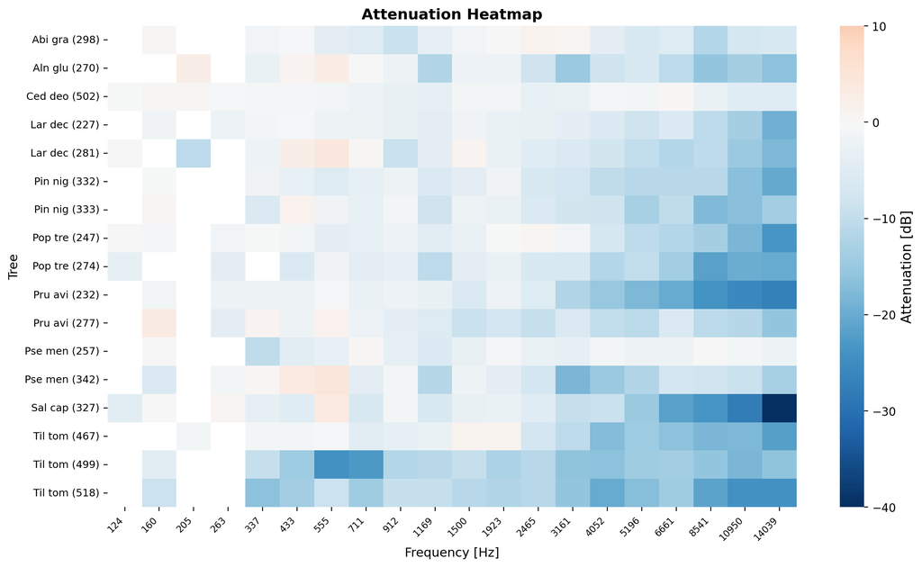

## Structural Traits (from TLS)

**Whole-tree metrics:**

- Height,
- Crown Volume,
- Volumetric Fill Fraction

**Density metrics:**

- Leaf Voxel Density at measurement height
- -> Gap Fraction

**Complexity indices:**

- ENL, FHD, LAD

## Height & Crown Volume & Volumetric Fill Fraction

```r
# Height: 1st to 99th percentile (avoids outliers)
height_m <- quantile(pts$Z, 0.99) - quantile(pts$Z, 0.01)

# Crown Volume: 3d convex hull
crown_volume_m3 <- tryCatch({
  hull <- convhulln(as.matrix(pts), options = "FA")
  hull$vol
}, error = function(e) NA)

# Volumetric Fill Fraction
...
    # Count voxels inside convex hull
    hull <- convhulln(as.matrix(pts))
    inside <- inhulln(hull, as.matrix(grid))
    n_hull_voxels <- sum(inside)

    # Ratio: occupied / possible
    n_voxels / n_hull_voxels
...
```

## Gap Fraction based on Densest Slice Height and Sound Direction

```r
compute_gap_fraction_with_projection <- function(vx, slice_pts, id_str, voxel_size) {
  # Get measurement angle
  angle_deg <- MEASUREMENT_ANGLES[[id_str]]

  ...

  theta <- angle_deg * pi / 180

  # Direction vector (horizontal plane, from speaker into tree)
  dir <- c(sin(theta), cos(theta), 0)

  # Walk along the sound array to find first intersection with points
  # -> find first voxel hit (hit_point)
  step <- voxel_size / 2
  start_point <- center3 - dir * (5 * CIRCLE_RADIUS)
  hit_point <- center3

  ...

  # Project all voxels onto plane perpendicular to sound path
  lateral <- c(cos(theta), -sin(theta), 0)
  vertical <- c(0, 0, 1)

  vx_mat <- as.matrix(vx[, c("x", "y", "z")])
  proj <- t(apply(vx_mat, 1, function(pt) {
    v <- pt - hit_point
    c(sum(v * lateral), sum(v * vertical))
  }))

  ...

  # Count voxels inside 3m radius circle above clip_bottom
  # ... 3m is randomly chosen, questionable
  d <- sqrt(proj_dt$u^2 + proj_dt$w^2)
  inside_mask <- (d <= CIRCLE_RADIUS) & (proj_dt$w >= clip_bottom)

  ...

  # Gap fraction = 1 - (occupied / total)
  gap_fraction <- 1 - (occupied / n_total)
```

## Gap Fraction: Tilia tomentosa (518)

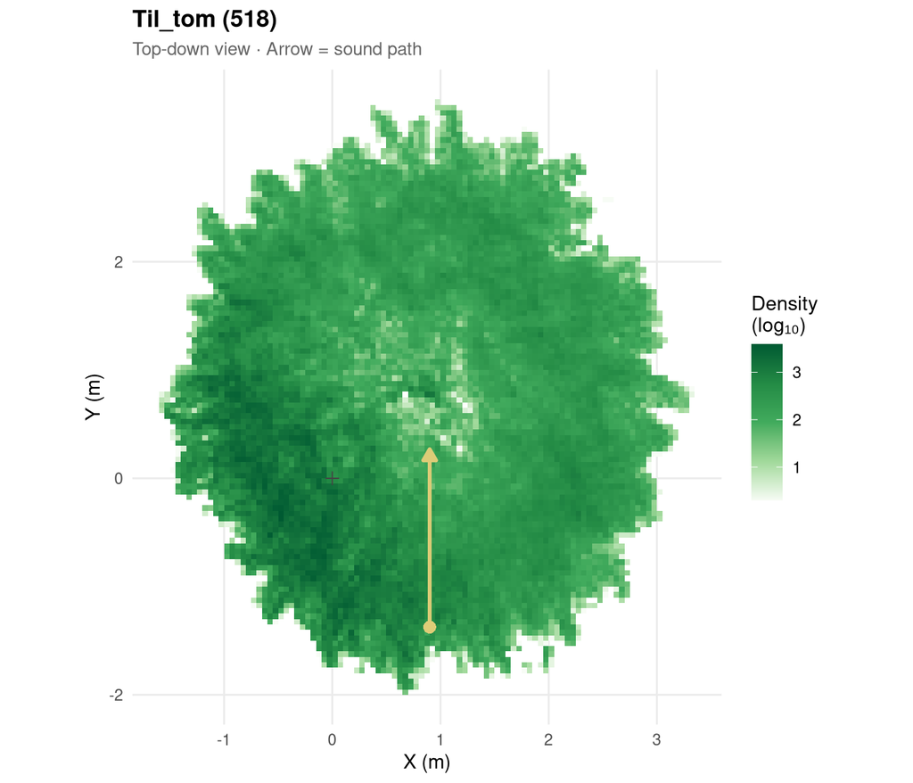

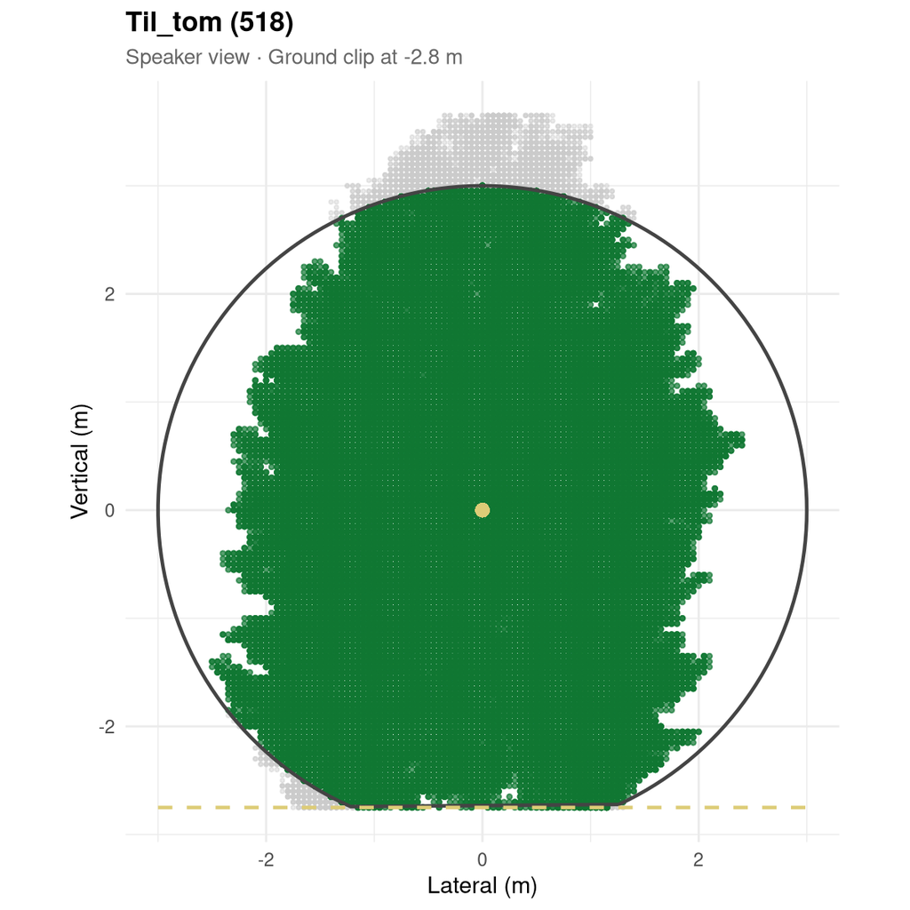

## Gap Fraction: Pinus nigra (332)

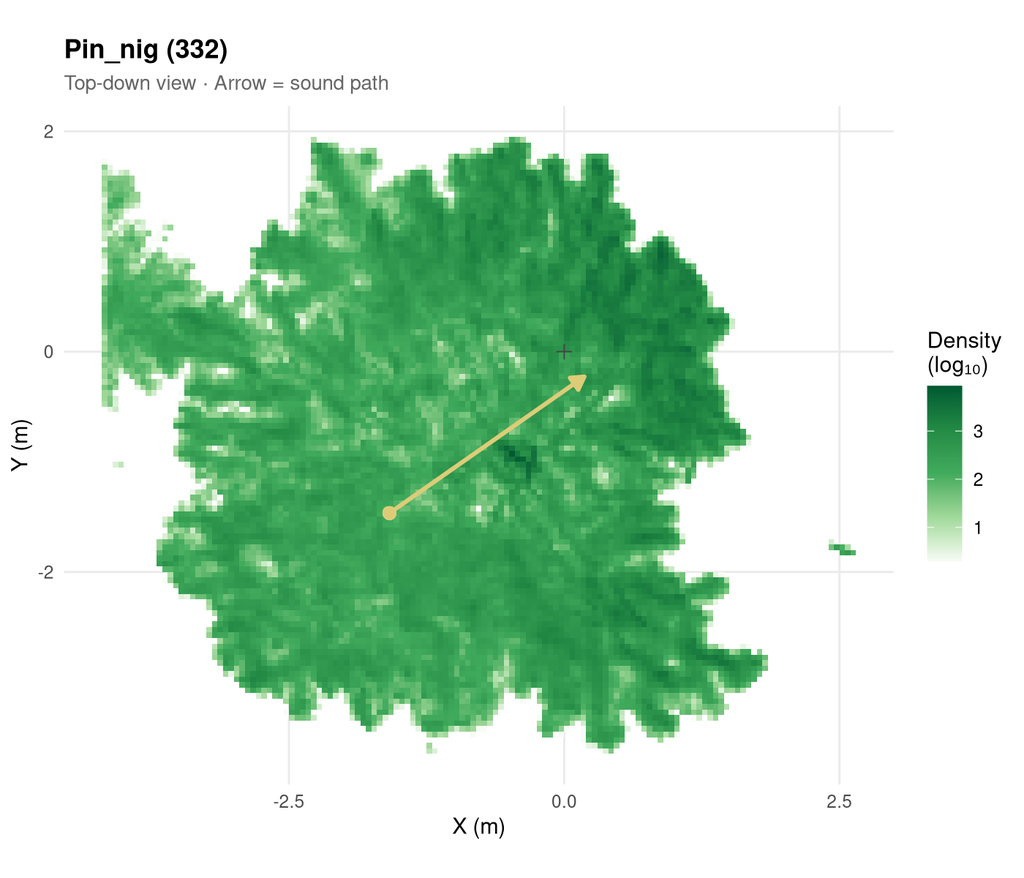

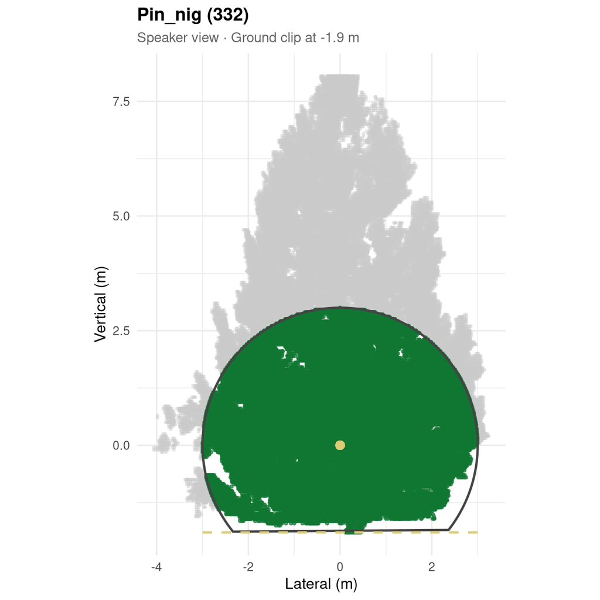

## ENL (Effective Number of Layers)

$$\text{ENL} = \frac{1}{\sum p_i^2}$$

**Single tree**: How many *effective* vertical foliage layers this tree has.

Ignores rare thin layers.

**Range**: ENL ≈ 1 (all foliage in one thick layer) to #occupied layers (evenly spread)

```r
# ENL (Effective Number of Layers) - Quantifies vertical canopy layering
# Measures how many effectively distinct height layers exist
# (1 = single layer, N = N even layers)

# Create 0.5m height bins from ground to tree top
enl_bins <- seq(0, max(vx$z) + 0.5, by = 0.5)

# Assign each point to its height bin
enl_bin_idx <- findInterval(vx$z, enl_bins, rightmost.closed = TRUE)

# Count points per height bin
enl_counts <- tabulate(enl_bin_idx, nbins = length(enl_bins))

enl_counts <- enl_counts[enl_counts > 0] # Remove empty bins

# Calculate proportion of points per occupied bin
enl_props <- enl_counts / sum(enl_counts)

# Simpson diversity index: 1/sum(p_i^2)
ENL <- 1 / sum(enl_props^2)
```

## FHD (Foliage Height Diversity)

$$\text{FHD} = -\sum p_i \log_2(p_i)$$

**Single tree**: How *diverse* the tree’s vertical foliage profile is (in bits).

Rewards even thin layers throughout.

**Range**: FHD ≈ 0, if all foliage in one layer to perfectly even at
$$\log_2(\text{#layers})$$

```r
FHD <- -sum(enl_props * log2(enl_props + 1e-12))  # Shannon entropy on layer proportions
```

## LAD (Leaf Area Density)

$$\text{LAI} = -\frac{\ln(\text{gap fraction})}{k}, \quad k = 0.5$$

$$\text{LAD} = \frac{\text{LAI}}{\text{crown depth}} \quad [\text{m}^2/\text{m}^3]$$

**Problem:** k=0.5 assumes ~50% light interception per LAI unit. Sound waves diffract around leaves (much larger λ),

so actual sound extinction << 0.5

```r
  # LAD (Leaf Area Density) - from gap fraction using Beer-Lambert
  # ... tried to adapt from ligt to sound, questionable
  LAD <- tryCatch({
    gf <- gap_result$gap_fraction
    if (is.na(gf) || gf <= 0 || gf >= 1) {
      NA
    } else {
      crown_depth <- max(vx$z) - min(vx$z)
      if (crown_depth <= 0) crown_depth <- 1
      LAI <- -log(gf) / 0.5  # Assuming extinction coefficient k = 0.5
      LAI / crown_depth
    }
  }, error = function(e) NA)
```

## Leaf Traits (from Measurement Table)

- **Average Leaf Area** (use “without petiole” for broadleaf and “with” for needleleaf)
- **Thickness** (average of 5 measurements per leaf)
- **LDMC = Leaf Dry Matter Content** (dry weight / fresh weight)
- **Toughness** (average again)

## Predictor Correlations

**Broadleaf**

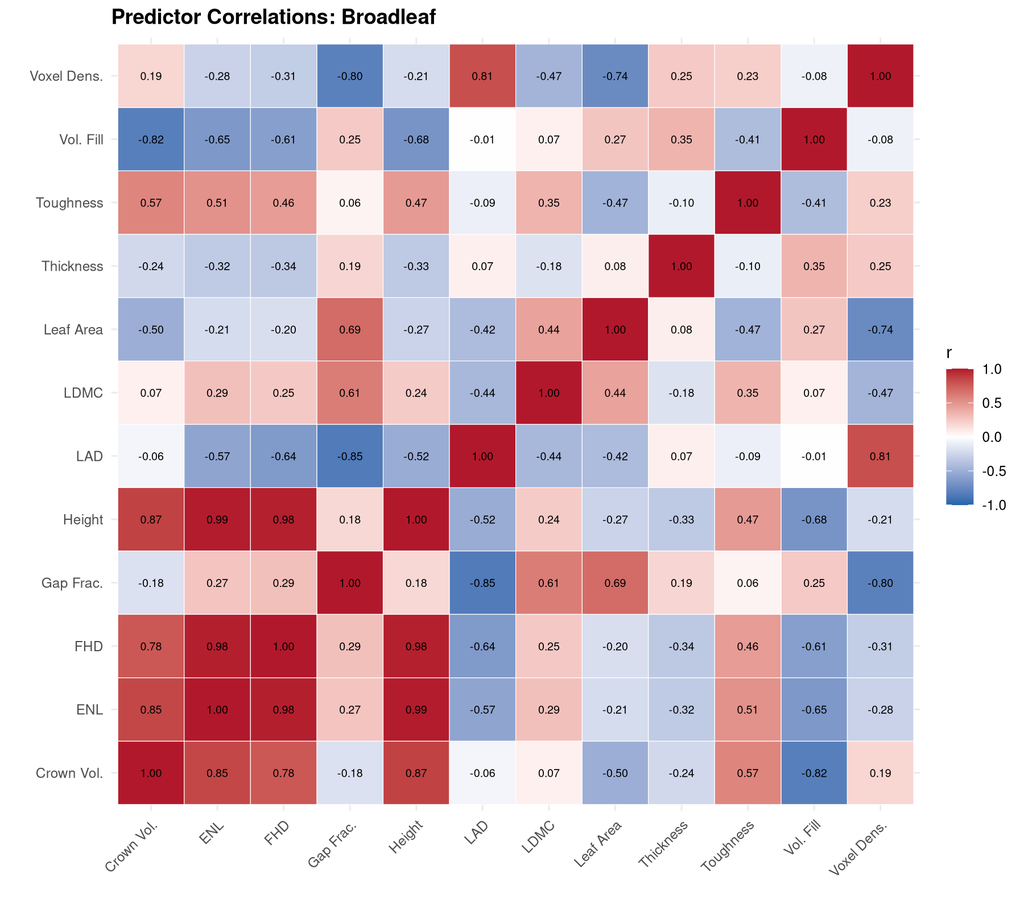

**Needleleaf**

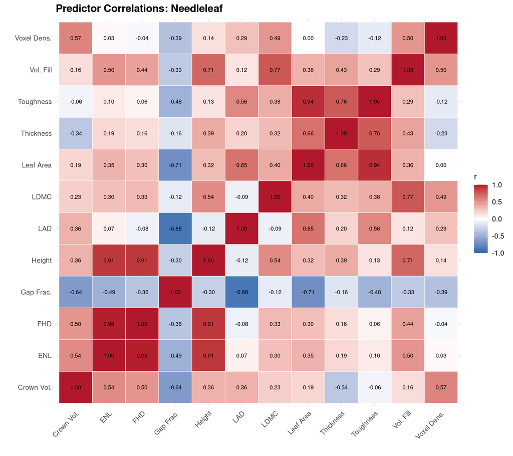

## Modeling: Forward Stepwise Selection

**Model type:** Simple linear regression (OLS)

**Procedure:**

1. Start with null model (intercept only)
2. Try adding each candidate predictor
3. Select predictor with best improvement according to criterion
4. Repeat until stopping condition met

**Maximum 3 predictors** (avoid overfitting with small n)

## Four Selection Criteria

| Criterion | Stopping Condition |
| --- | --- |
| **Adj. R²** | ΔAdj.R² < 0.02 |
| **BIC** | ΔBIC ≥ 0 |
| **LOOCV RMSE** | ΔLOOCV ≥ 0 |
| **F-test** | p-value > 0.15 |

Each criterion evaluated independently to compare selection strategies.

## Stepwise: Broadleaf Adj R²

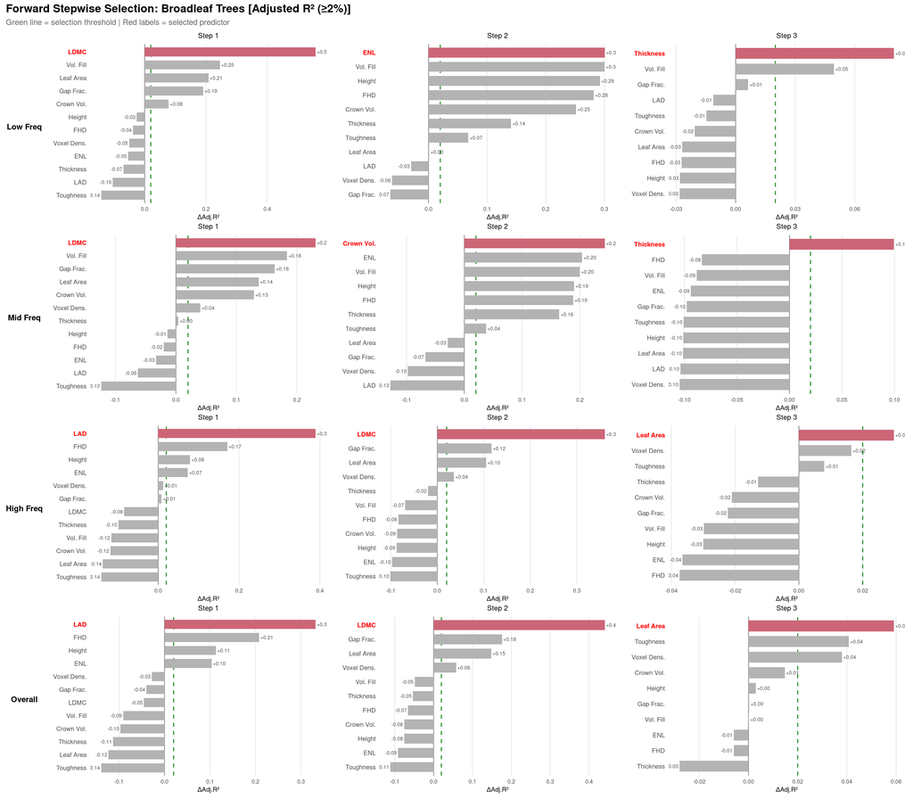

## Stepwise: Broadleaf BIC

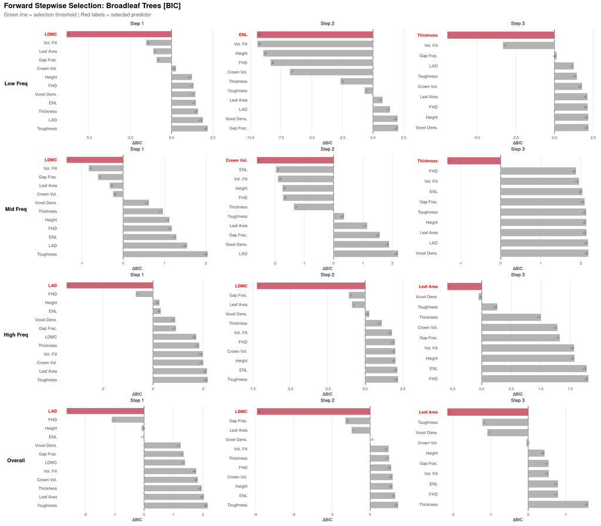

**Selected Predictors**

**Low freq**: `ldmc` → `ENL` → `thickness`  
**Mid freq**: `ldmc` → `crown_vol` → `thickness`  
**High freq**: `LAD` → `ldmc` → `leaf_area`  
**Overall**: `LAD` → `ldmc` → `leaf_area`

## Stepwise: Broadleaf F-test

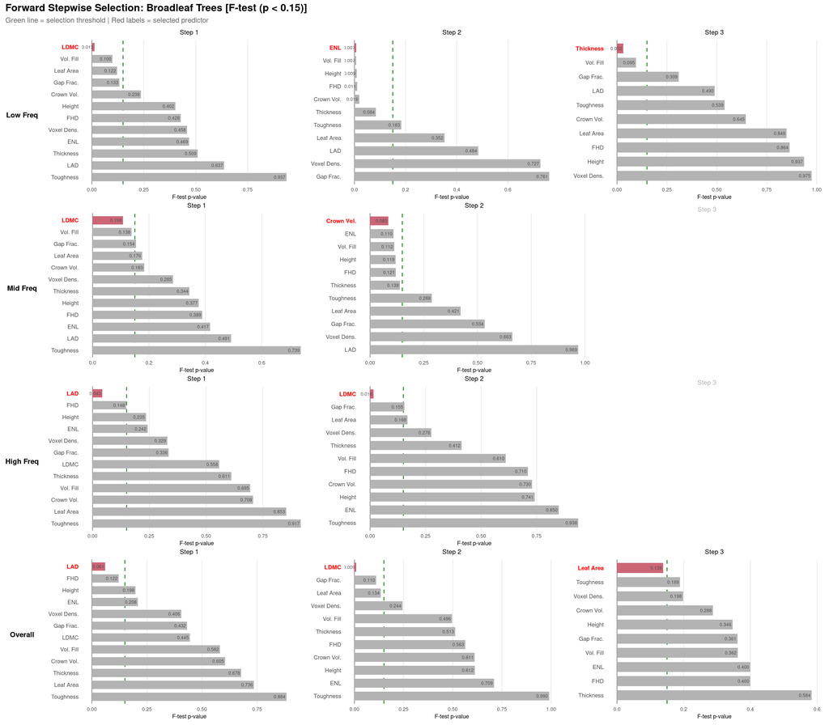

**Selected Predictors**

**Low freq**: `ldmc` → `ENL` → `thickness` **Mid freq**: `ldmc` → `crown_vol` **High freq**: `LAD` → `ldmc` **Overall**: `LAD` → `ldmc` → `leaf_area`

## Stepwise: Broadleaf LOOCV

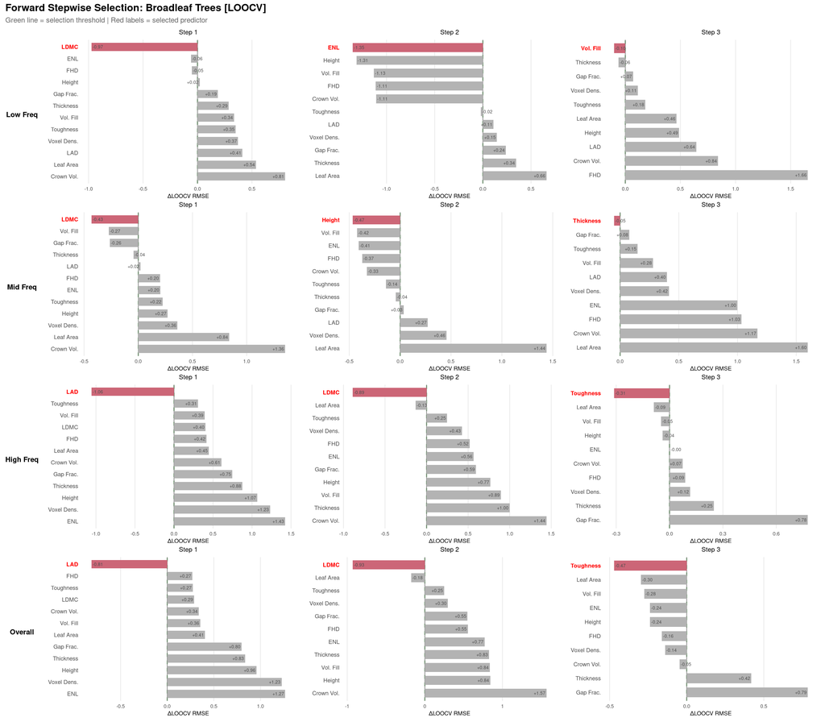

**Selected Predictors**

## Stepwise: Needleleaf Adj R²

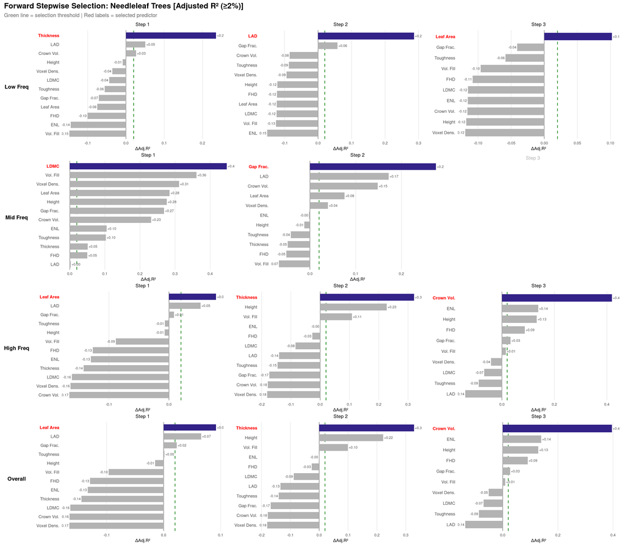

**Selected Predictors**

## Stepwise: Needleleaf BIC

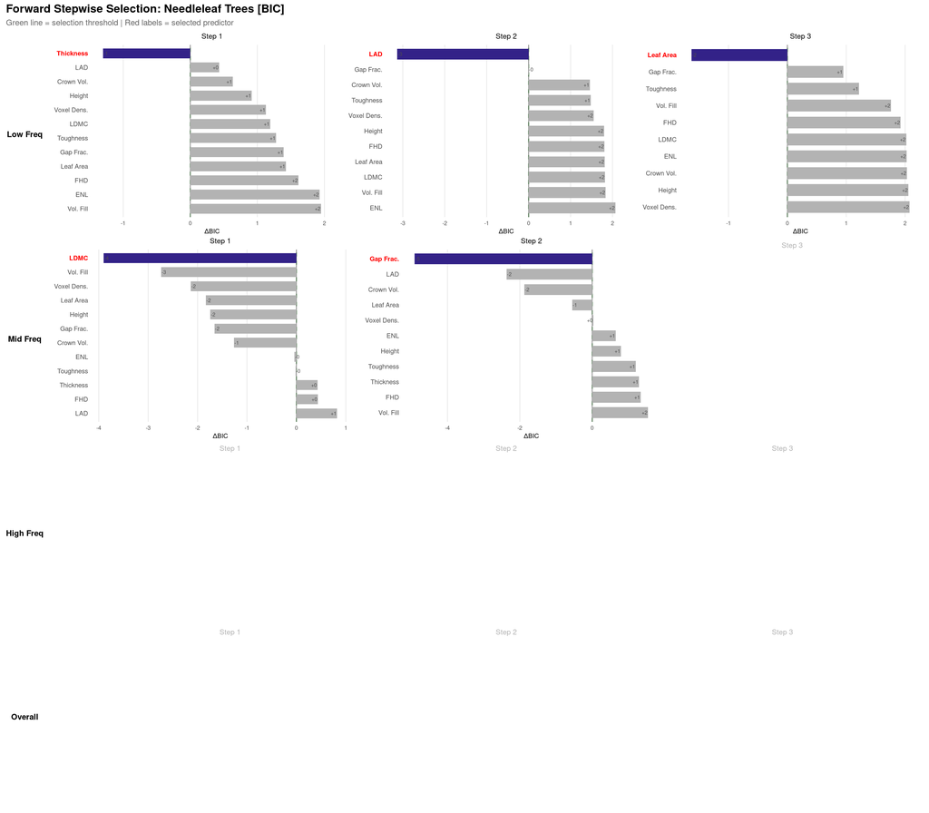

**Selected Predictors**

**Low freq**: `thickness` → `LAD` → `leaf_area`  
**Mid freq**: `ldmc` → `gap_fraction`  
**High freq**: (null model)  
**Overall**: (null model)

## Stepwise: Needleleaf F-test

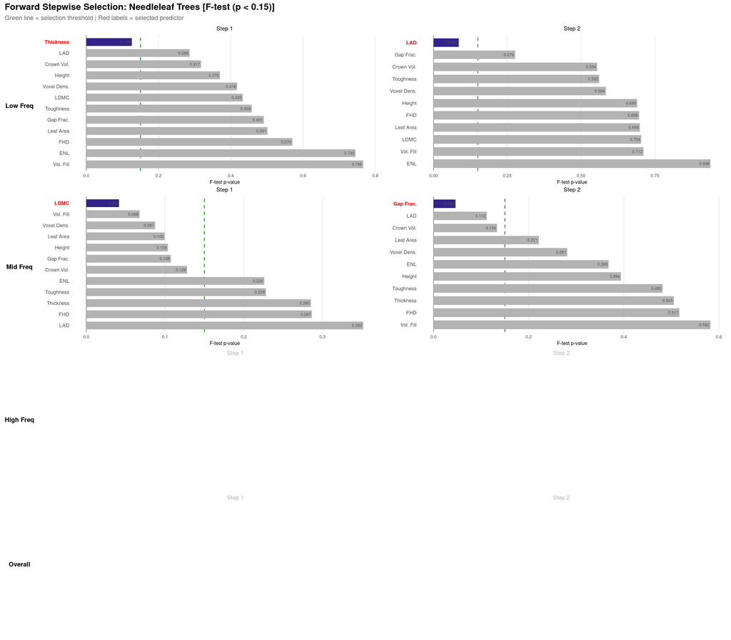

**Selected Predictors**

**Low freq**: `thickness` → `LAD`  
**Mid freq**: `ldmc` → `gap_fraction` **High freq**: (null_model) **Overall**: (null_model)

## Stepwise: Needleleaf LOOCV

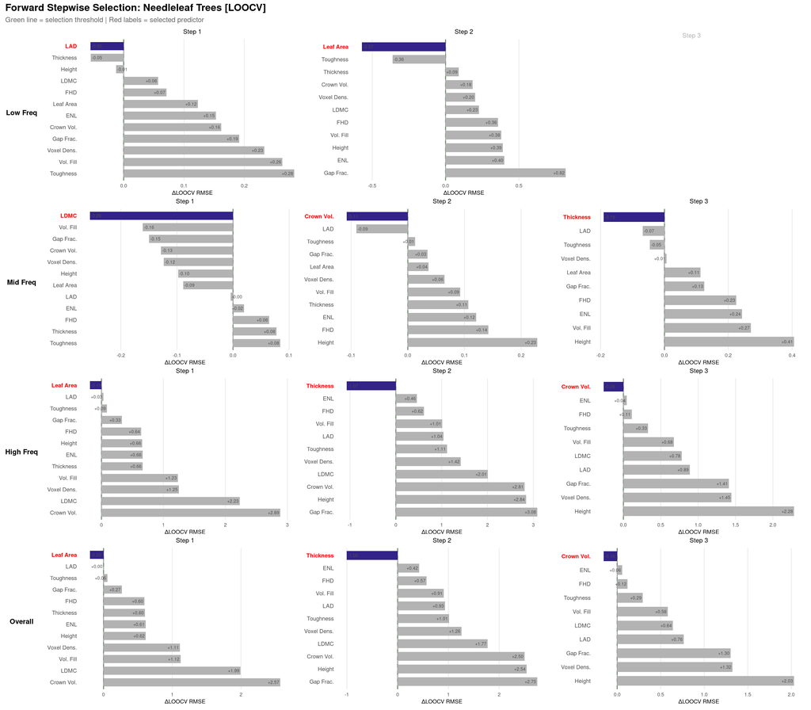

**Selected Predictors**

## Model Fit: Broadleaf Adj R squared

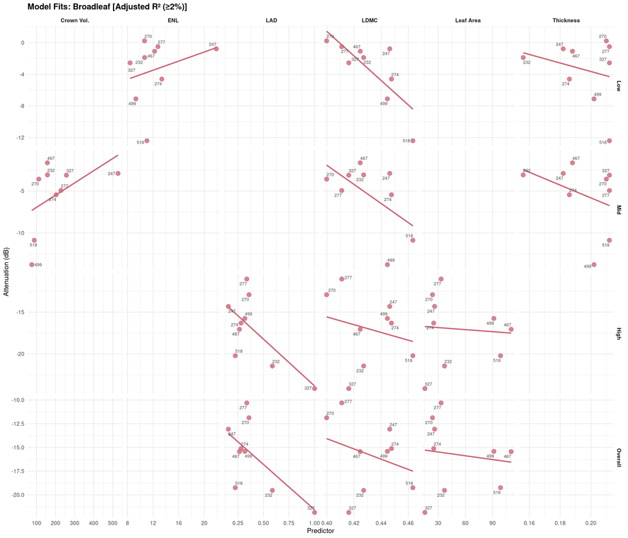

## Model Fit: Broadleaf BIC

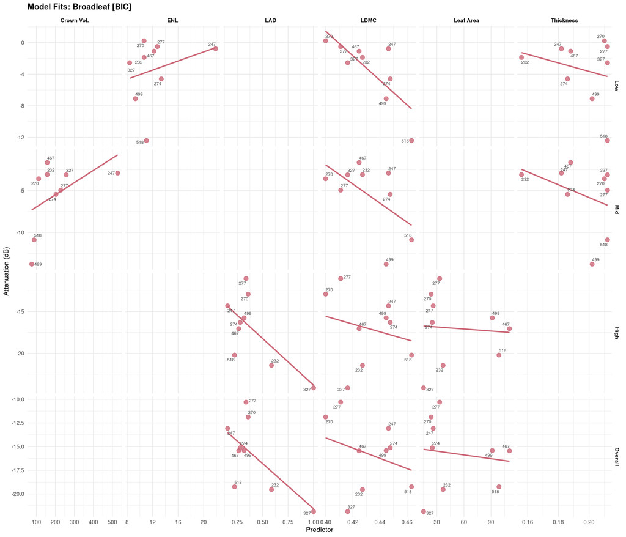

## Model Fit: Broadleaf F Test

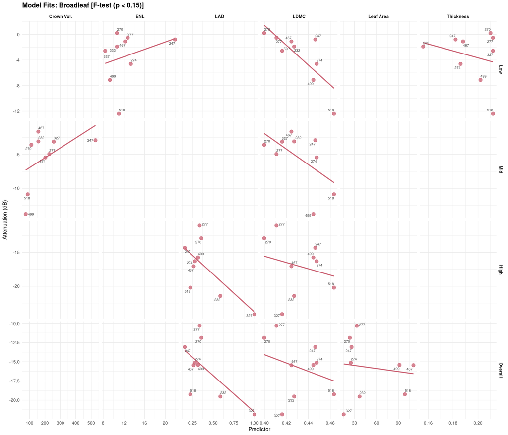

## Model Fit: Broadleaf LOOCV

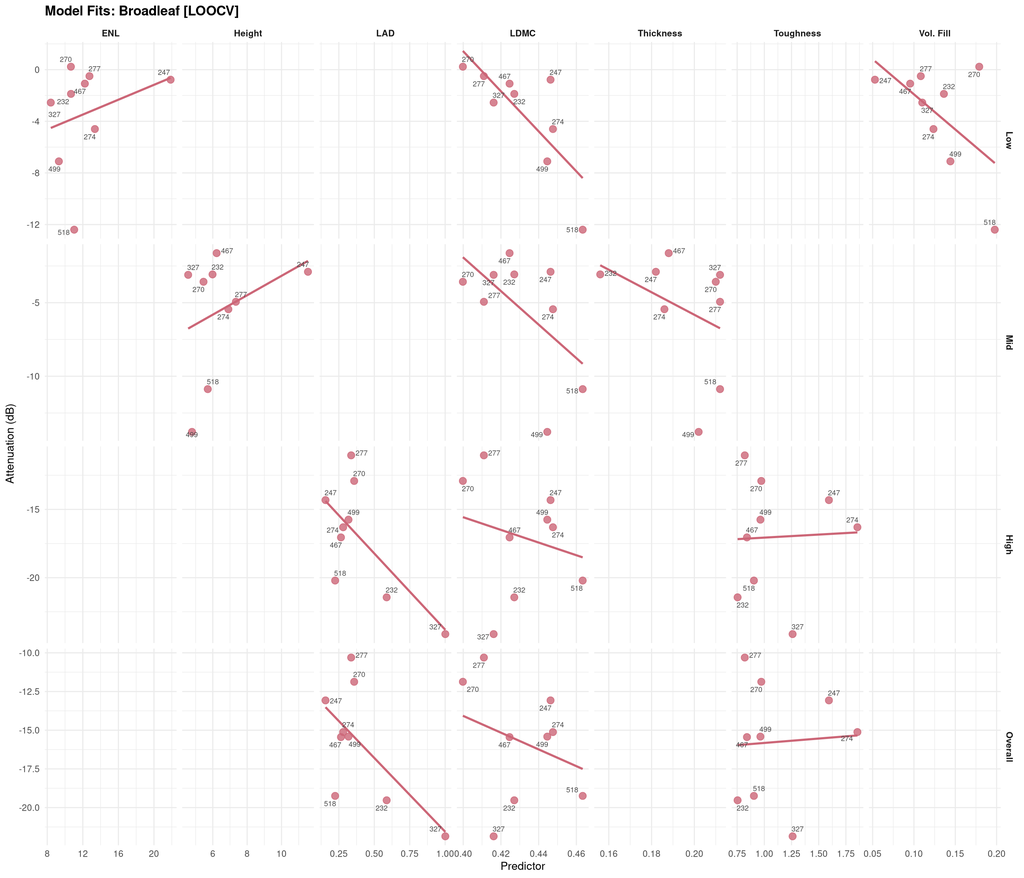

## Model Fit: Needleleaf Adj R squared

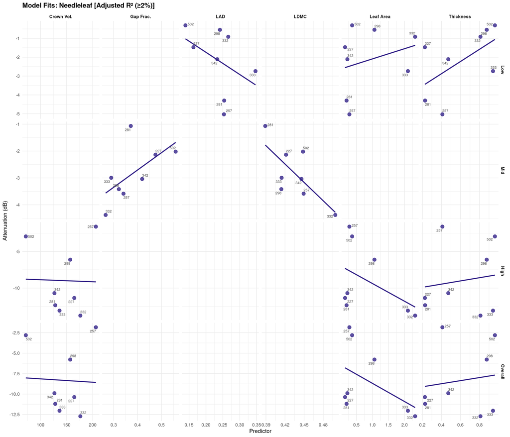

## Model Fit: Needleleaf BIC

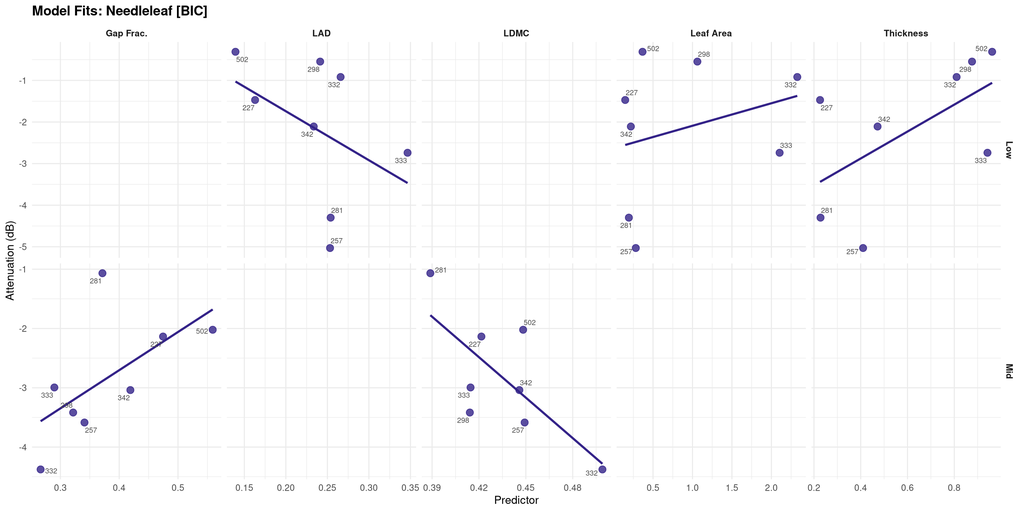

## TFs by Gap Fraction

**Broadleaf**

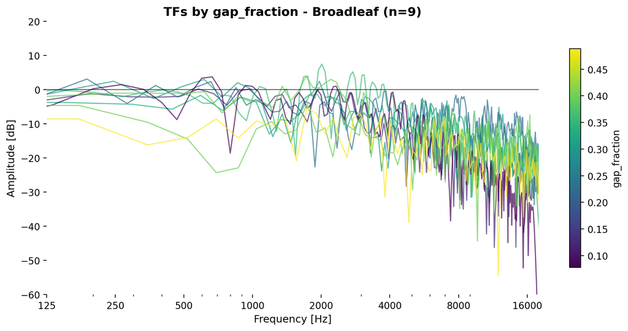

**Needleleaf**

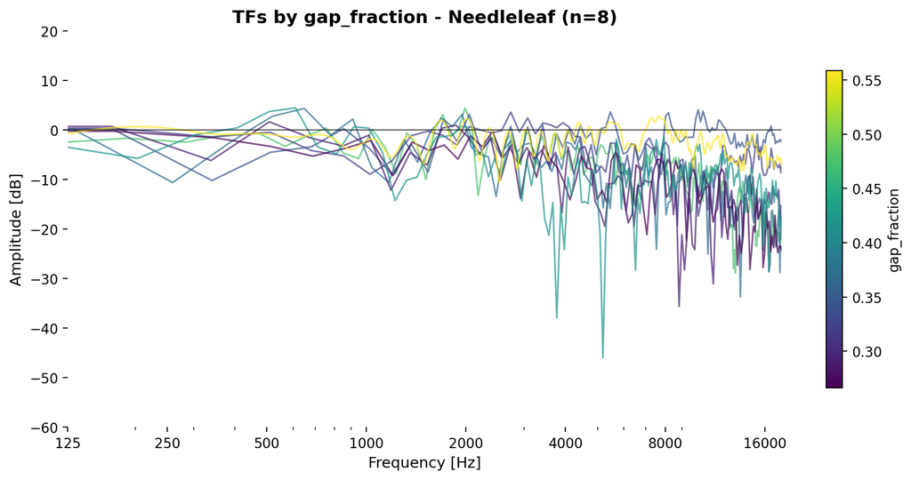

## TFs by LAD

**Broadleaf**

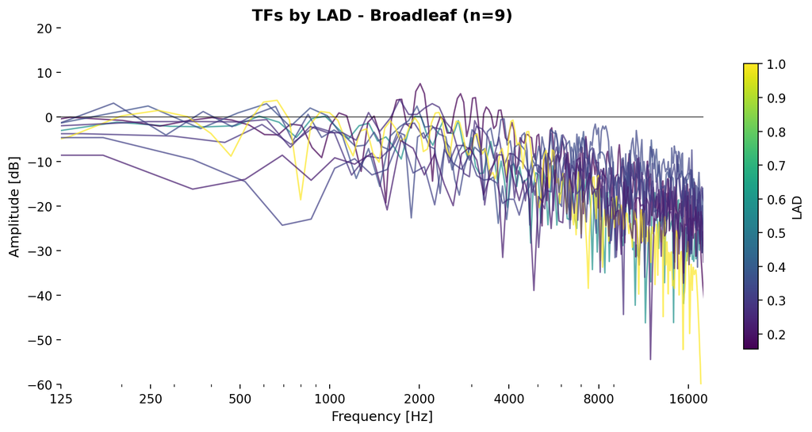

**Needleleaf**

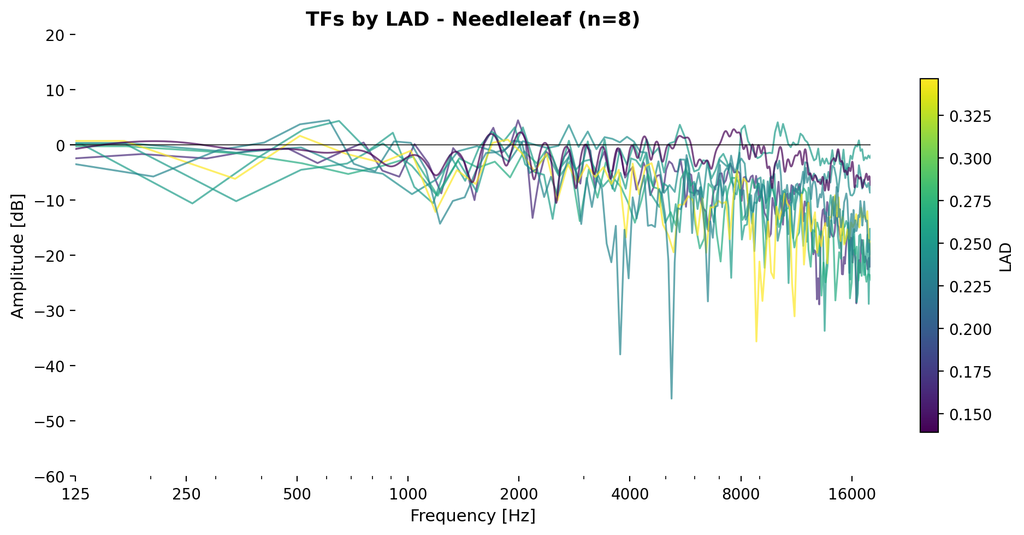

## TFs by ENL

**Broadleaf**

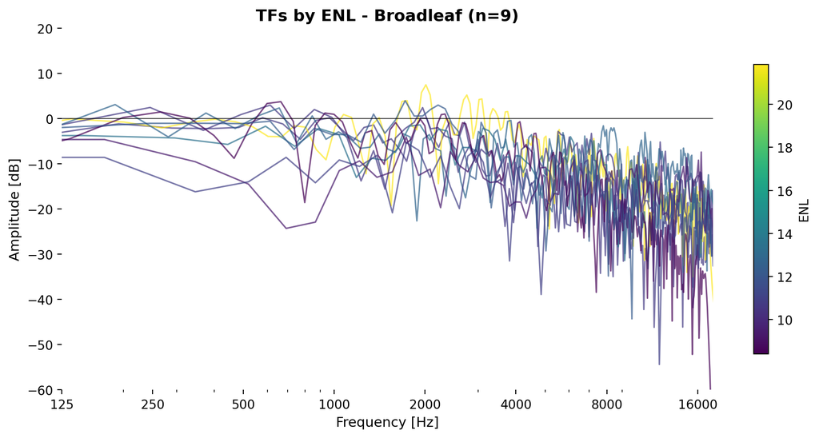

**Needleleaf**

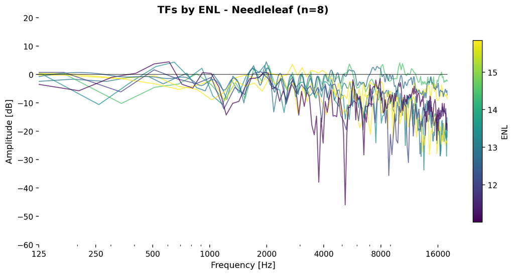

## TFs by LDMC

**Broadleaf**

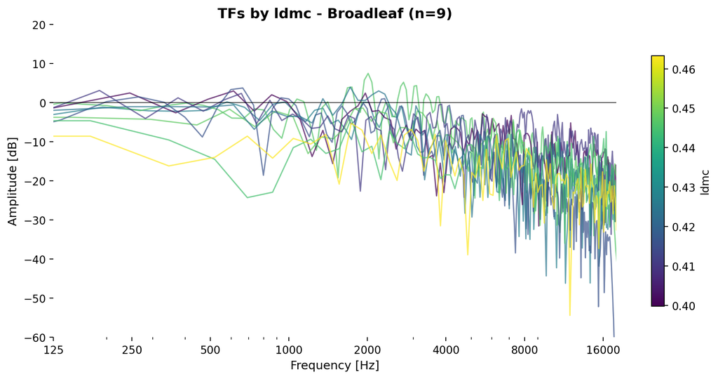

**Needleleaf**

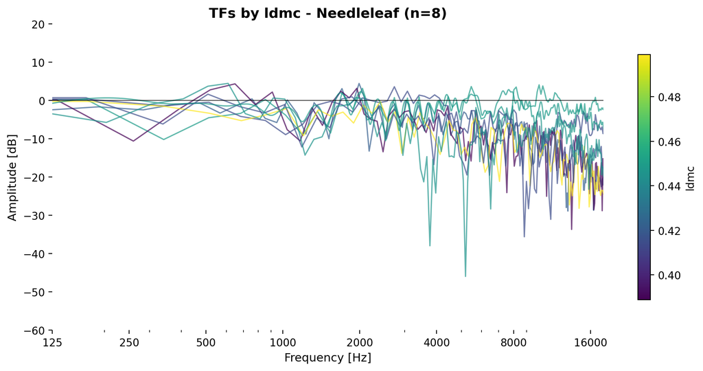